# Part II - Factors Affecting Borrower APR

## Dataset Overview

The data set contains 113,937 loans with 81 variables on each loan, including loan amount, borrower rate (or interest rate), current loan status, borrower income, and many others.

## (Visualization 1)

### Univariate exploration of Borrowers APR data

The distribution of APR shows a multi-modal data. The histogram shows a small peak centered at 0.09, a large peak centered at 0.17. There is also a slightly lower peak centered 0.2 and a also a little lower than 0.2 peak at 0.29, also a peak(slightly lower than 0.29 peak) at 0.36.The Highest peak was recorded at 0.17 and the lowest at 0.4. Statistics shows that very few people have an APR >= 0.4,at 0.5, there were no data records. The most people have an APR of 0.17, followed by 0.2, then 0.15 and 0.3. A high APR means that the customer will be paying a higher interest rate on money borrowed.

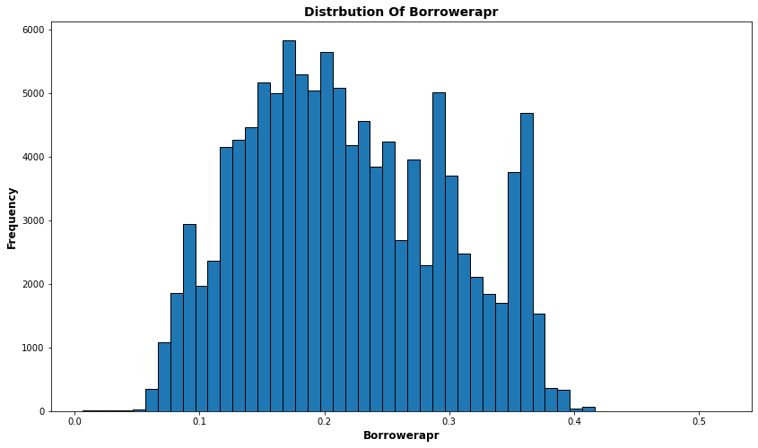

## (Visualization 2)

### Finding Correlations between the features of my interest and Borrowers APR using bivariate exploration technique

#### Key insights deduced from Visualization 2

1) BorrowerAPR and BorrowerRate have a very strong correlation coefficient of 0.99. This is Great!. Having a high APR typically means borrowers will be paying more interest on their loans.

3) Deducing from the statistics; The higher the LoanOriginalAmount, the higher the MonthlyLoanPayment.

4) The correlation coefficient of the LoanOriginalAmount and StatedMonthlyIncome is 0.20 showing a very slight positive relationsip between the two variables.

5) Very strong positive correlation between loan original amount and monthlyloan payment

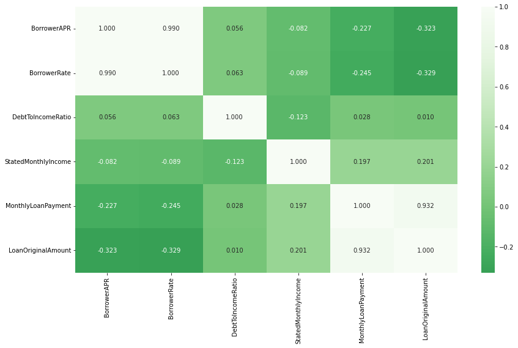

## (Visualization 3)

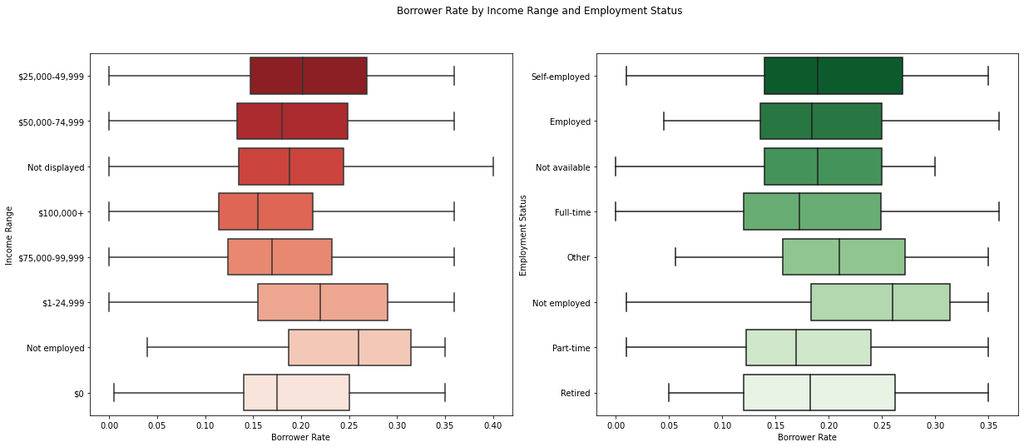

## (Visualization 4)

#### Key insights deduced from Visualization 4

1) In the distribution of rating and loanterm correlation; over 10000 borrowers who who took a 36month (3years) term loan, rated "A" which was the highest rating followed by "C" (rated by same 36month term borrowers) and closely followed by "D".

2) The highest number of borrowers(8000) who took the 60month term plan (5 years) rated "C", followed by about 6000 borrowers from the 60month term who rated "B".

3) Very few people (< 500) opted for the 12month plan and there was no significant difference in the ratings for it.

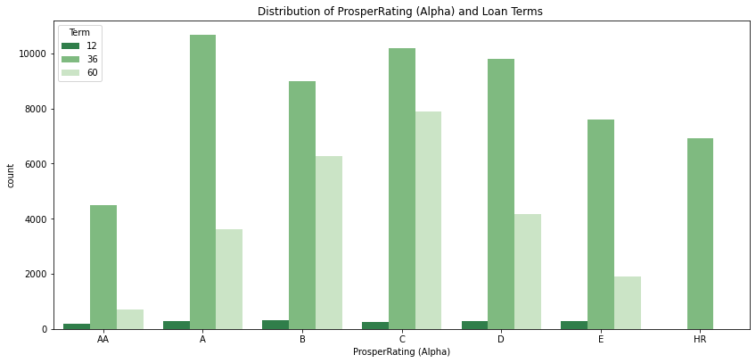

## (Visualization 5)

### Visualizations showing the multivariate relationship between Borrower APR, rating, loan term and Original loan amount.

#### Key insights deduced from Visualization 5

1) The APR decreases with the increased of loan term for C - HR ratings.

2) For AA-B ratings, the APR increases with the increased of loan term.

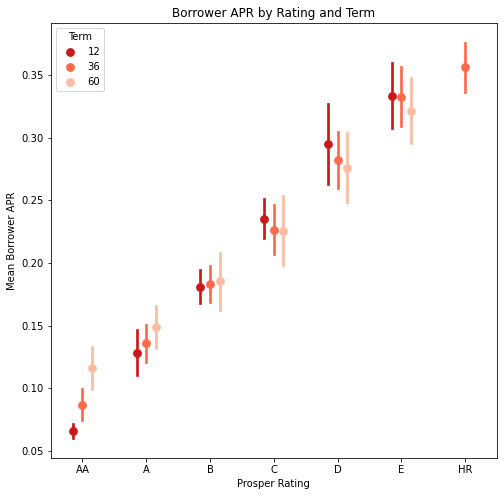

## (Visualization 6)

### key insights deduced from Visualization 6

1) There is a positive relationship between borrower APR and Prosper rating "AA"

2) The relationship between borrower APR and loan amount turns from negative to slightly positive when the Prosper ratings are increased.

3) The borrower APR decreases with better rating.

4) The loan amount increases with better rating.

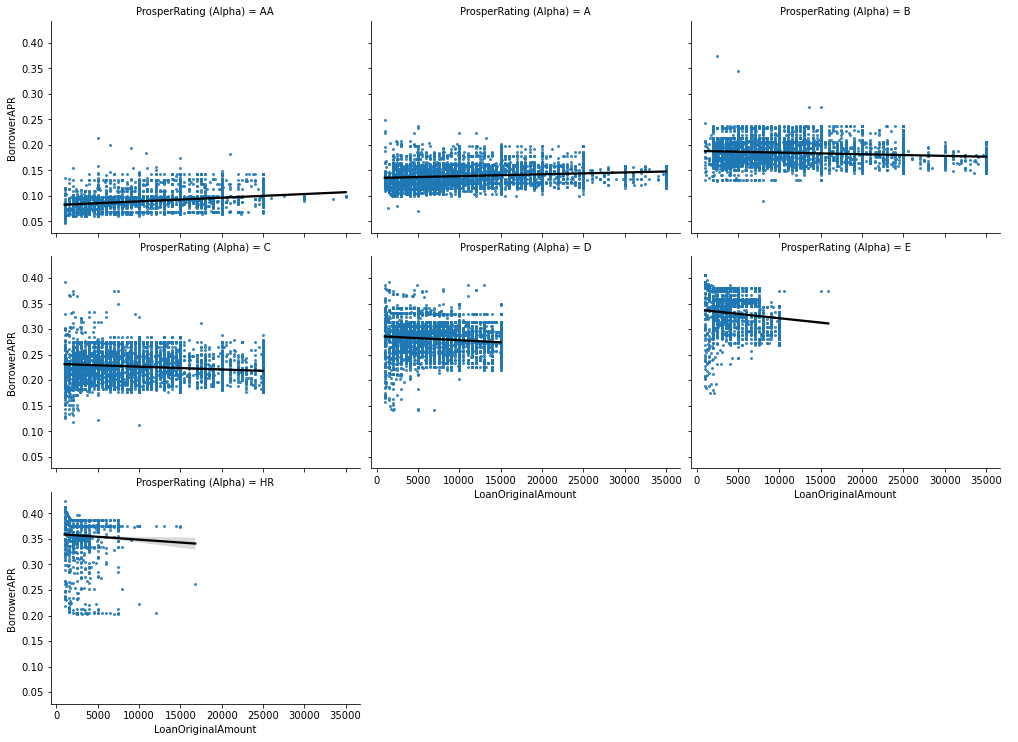

## (Visualization 7)

### Borrower APR and Original Loan Amount

#### Key insight deduced from this visualization

1) The borrower APR decreases with increased loan amount

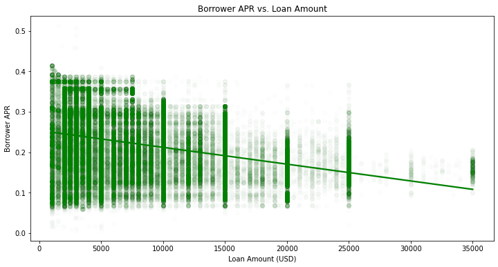